# R Workshop ISTS 2018 - Getting Started

# Introduction

Thank you for signing up to attend my R workshop at 2018 ISTS meeting in Kobe, Japan. I look forward to meeting with you. Just to get us started, I put together a brief introductory document. This will be a hands-on workshop where you will be using your laptop to learn how to manipulate data in R, conduct statistical analyses, and make publication ready figures. At the end of this workshop, you will have example code to conduct data analyses of your own using R.

I have taught similar R workshops a couple times. I have taught gradulate level statistics classes using R at Moss Landing Marine Laboratories in California, USA, as a visiting lecturer in 2012 and 2013. I have also organized Bayesian statistics workshops at the Bienniel Conference on Marine Mammals and past ISTS meetings. I hope you’ll learn new things during the workshop and find R to be a useful tool in your future research projects.

# Preparing for the workshop

Although R can be used by itself and with a text editor, I use RStudio, which combines a text editor, R console, data viewer, package organizer, help viewer, figure viewer, etc. It is free and is used by many R programmers. They also provide free webinars on a wide variety of topics. They even organize annual conferences. I encourage you to use RStudio and I will use it in this workshop. Please install R first, then RStudio, before the workshop. R can be found here (https://cran.r-project.org/) and RStudioe here (https://www.rstudio.com/).

Because we want to start without worrying about installing R and RStudio at the workshop, I prepared a geting-started document. Please follow the process below and see if your RStudio and R are installed correctly before Wednesday, February 14, 2018. If you encounter problems, please let me know.

Once you think you have installed RStudio and R, please create a new project by clicking on the upper right corner of the screen.

Followed by selecting “Empty Project”:

[figure not shown]

Then, select a new directory:

[figure not shown]

Enter an appropriate directory name:

[figure not shown]

You should have created a new project in a new directory. All subsequent files related this project can be dropped into this folder. Here is what mine looks like. The color scheme is different because the image was created using an older version of RStudio.

[figure not shown]

If you want to change the color scheme (I like dark background, which seems to be kinder on my eyes), you can go to Tools - Global Options and select a different appearance, like so:

[figure not shown]

Once this is setup, please download the test file I created in the Google drive (https://drive.google.com/open?id=0BzryQfL97RxZNWZ6VkMzelJSSXc) called “turtle_R_Workshop.R”. Place the file into the newly created directory, in my case “C:/Users/tomo.eguchi/Documents/R/ISTS2018_R_Workshop” and open it in RStudio then “source” it:

[figure not shown]

If you already installed the ggplot2 package, you may see a warning message. You can stop it and comment out the install.packages line by placing a # at the beginning of the line and run it again. You should see some summary statistics and a plot like this:

```
     length            mass
 Min.   : 44.12   Min.   : 15.04
 1st Qu.: 66.93   1st Qu.: 38.16
 Median : 84.93   Median : 81.80
 Mean   : 83.52   Mean   : 96.28
 3rd Qu.:100.50   3rd Qu.:149.95
 Max.   :114.15   Max.   :245.77

Call:
lm(formula = log(mass) ~ length, data = df1)

Residuals:
     Min       1Q   Median       3Q      Max
-0.20157 -0.06946 -0.00798  0.06642  0.22695

Coefficients:
             Estimate Std. Error t value Pr(>|t|)
(Intercept) 0.9939459  0.0429421   23.15   <2e-16 ***
length      0.0396017  0.0005004   79.14   <2e-16 ***
---
Signif. codes:  0 ‘***’ 0.001 ‘**’ 0.01 ‘*’ 0.05 ‘.’ 0.1 ‘ ’ 1

Residual standard error: 0.09858 on 98 degrees of freedom
Multiple R-squared:  0.9846,    Adjusted R-squared:  0.9844
F-statistic:  6263 on 1 and 98 DF,  p-value: < 2.2e-16
```

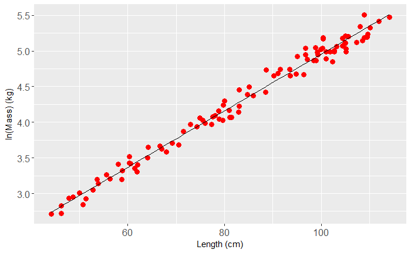

You are all set!

# Some (unsolicited) advise and a few words on R

R is a statistical environment that is available free for anyone. It started as a dialect of S and S+ but turned into a full fledged statistical software. I think almost all statisticians use it around the world. Other statistical packages are becoming somewhat obsolete as they are often expensive. I strongly suggest using R for all your analyses.

R can be used alone by using the console (only for very rudimentary analysis), write scripts in a text editor (more on this later) and running them in R, or use an integrated editor, such as RStudio. There are many others but RStudio is my favorite and many others use it also. So, we’ll use it! RStudio, and other integrated editors, helps with updating R and R “packages” as well as many other functions.

There are hundreds of “packages” that can be added to R to do specific analyses. Almost all of the packages can be found at the CRAN website (http://cran.r-project.org/). Finding which packages to use is not a trivial task sometimes. You need to communicate with others in your field or search the Internet.

To install a package, you use the install.packages() function. For example, “install.packages(”AGD“)”. The package supposed to have functions to analyze growth data. The installation process downloads the package (or packages) and other necessary packages, if needed on your computer. Hopefully, you won’t see any error messages and it should end with a comforting message: “package ‘AGD’ successfully unpacked and MD5 sums checked”

To use the package, you need to call it in your work space (or in your script) using the library command; “library(AGD)”. We’ll go through this process a few more times as needed throughout this workshop.